# Coursework Report

*N* removed NAs: 5

*N* removed <18: 25

**Correct typo age:** 20

*N* total clean: 138

| Group | *N* | *M*<sub>age</sub> | % green |
| --- | --- | --- | --- |
| Control | 66 | 20.50 | 35.86 |
| Experim | 72 | 20.64 | 51.85 |

| Gender | *N* | *M*<sub>age</sub> | % green |
| --- | --- | --- | --- |
| Female | 64 | 20.44 | 45.83 |
| Male | 45 | 20.67 | 41.48 |
| Other | 29 | 20.72 | 44.83 |

**Main analysis results**

**car:**  
χ<sup>2</sup>(1) = 3.19, *p* = .074

**cleaner:**  
χ<sup>2</sup>(1) = 8.59, *p* = .003

**dishwasher:**  
χ<sup>2</sup>(1) = 0.18, *p* = .669

[interactive chart not shown]

[figure not shown]

[interactive chart not shown]

# Coursework Report

Analysing Data, Spring 2020

# Methods

## Participants

the below descriptive shows the descriptive statistics of gender in regards to age

**Descriptive statistics by gender**

| gender | n | mean_years | sd_years | % |
| --- | --- | --- | --- | --- |
| female | 191 | 20.44 | 1.84 | 46.25 |
| male | 135 | 20.67 | 1.88 | 32.69 |
| other | 87 | 20.72 | 1.79 | 21.07 |

## Design

The Conceptual hypothesis of this replication is “activating status motive is associated with high frequency of buying green product”

2. Operationalisation of variables used in the analysis
   - Condition: (factor) the study had two conditions, control and experiment. Participants were told they are going to participate in several studies and then asked to read a short story for a memory concerned study and then asked to made several numbers of choices as a part of other study that concerned product preferences to minimize potential suspicious. Both stories are with similar length (around 700 words)
     - Experimental condition story: the story talks about students imagined graduating and looking for a job in a big company that offers higher chance of moving up. It talks about the first day at work and how fascinated the student was with everything. Finally the story ends with the student moving up to a status that is relative to his/her same sex peers.
     - Control condition story: the story talks about losing a concert ticket and the journey of searching for the ticket in the house and ends with finding the ticket and going to the concert with same-sex peers.
   - Product: (factor) the next level asking participants to make several choices, for the first choice, participants were asked to imagine they were out shopping for three specific products, car, dishwasher and cleaner that are available in both green and luxury forms which were presented equal in price and produced by the same company

The Operational hypothesis statement is people in experimental condition will choose green product more likely than people in control condition and in order to examine this hypothesis the chi-squared test.

# Results

From the data, there is a pattern between the activation of status motives and buying green product as the data shows that participants in the experimental condition choose the green product more often than participants in the control condition.

Below is the three frequencies table for each product (car, cleaner and dishwasher) in both conditions

**Expected frequencies of car product choices by condition**

|  | luxury | green |
| --- | --- | --- |
| control | 37.01 | 27.99 |
| experimental | 40.99 | 31.01 |

**Expected frequencies of cleaner product choices by condition**

|  | luxury | green |
| --- | --- | --- |
| control | 34.91 | 31.09 |
| experimental | 38.09 | 33.91 |

**Expected frequencies of dishwasher product choices by condition**

|  | luxury | green |
| --- | --- | --- |
| control | 38.26 | 27.74 |
| experimental | 41.74 | 30.26 |

Below are the bar plots for each product separately

**car**

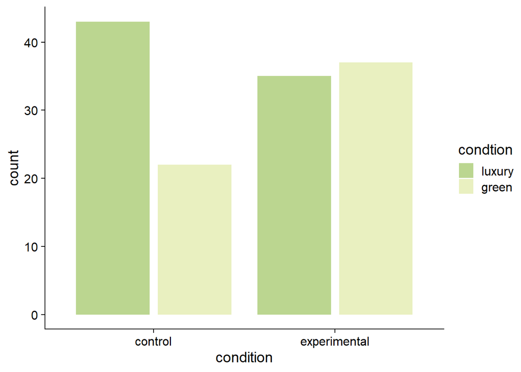

**cleaner**

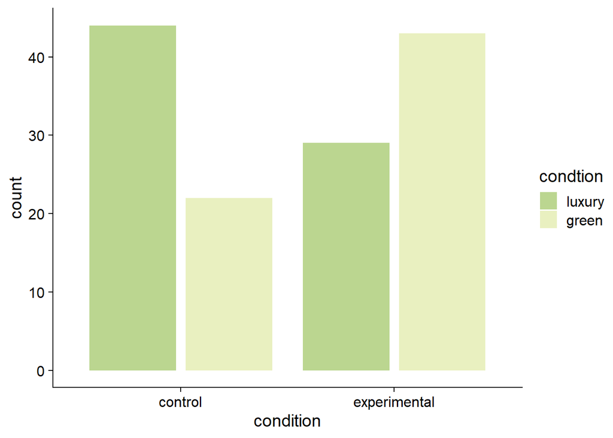

**dishwasher**

[figure not shown]

# Discussion

These results have been suggested by significant number of papers. on of those papers is Hartman and his colleagues Apaolaza paper(2012) that examine how to make effective marketing campaign toward green products. they conclude that in order to make a good campaign toward environmental products, the focus should not just be on environmental concerns but also to the psychological benefits as they argue that self expressive benefits is associated to individuals attitudes to the brands and their purchase intentions. This means that an effective campign must focus on how buying the product is going to affect people and their relationships wiht others not the environment.

Moreover, Thordtein Veblen theory “the theory of Leisure class” suggested that expensive products are labeled as conspicuous consumption which means the attaining of costly products to impress other individuals which can be used as a sexual selection tactic (Miller, 2000). while Sundie and his colleagues (2010) saw they conspicuous consumption play the same role Peacocks’ tail play in sexual selection as peacocks with the largest tails are seen more attractive than peacocks with small tails. the same way with human as people evaluate and place each others in positions depends on the product they consume which explain why people buy luxury brands product despite the quality as what matter conspicuous consumption and impressing others.

Bennet and Chakravarti(2009) argued that products it selves has a signaling potential and that products with higher signaling potentials deliver greater benefits from social behaviors that products with higher signaling potential. This explain why people vary in their product choice.

**Limitations**

It has been suggested that people are more willing to behave in a way that benefits the society when signaling is likely (Hartman et.al., 2010). This means that the desire of consuming green product increase only in public and being in a study with people you do not know may not be as public as enough for the desire of buying luxury products to come up. considering that participants’ status motive may be activated but the environment around them is not suitable for it to work which can be used to explain the choice of non-green product by participants in experimental condition.

another point to be taken in consideration is the way participants were told those are more than one study that concerns more than one topic and that the story they read concerns a memory study might make participants worrying about the story and trying to remember it cause they know a question about it is coming anytime. this might have lead to participants losing focus on the questions followed the story and even might have resulted in some wrong answers that were said unconsciously by participants whose minds’ are thinking about something else.

Another point is that as people differ in their personalities and their backgrounds, their choices will be affected by that as it has being argued that culture play a big role in people choices of product. For instance, people with personalities that love cleaning is more likely to choose the cleaner or the dishwasher than the car. On the other hand people who came from poor backgrounds are less likely to choose the green product due to the lack of awareness or knowledge. and the choices varies as the personalities and backgrounds varies.

For future studies, I would suggest to add a third condition which include participants who experience both conditions, first control and then experimental to observe the differences in their product choices without the interruption of other factors related to individuals differences. Final point is selecting people from similar backgrounds so that traditional principles and their culture will not affect the validity of the data. in addition to that, examine the association between backgrounds, culture and personalities and the product selection will do good as well.

# References

A. Bennett and A. Chakravarti (2009). Advanced in Consumer Research, 36 (2009), pp. 49-50.

Hartmann, P., & Apaolaza-Ibáñez, V. (2012). Consumer attitude and purchase intention toward green energy brands: The roles of psychological benefits and environmental concern. Journal Of Business Research, 65(9), 1254-1263. doi: 10.1016/j.jbusres.2011.11.001.

Miller, G. F. (2000). The mating mind: How sexual choice shaped the evolution of human nature. London, England: Heinemann.

Sundie, J., Kenrick, D., Griskevicius, V., Tybur, J., Vohs, K., & Beal, D. (2011). Peacocks, Porsches, and Thorstein Veblen: Conspicuous consumption as a sexual signaling system. Journal Of Personality And Social Psychology, 100(4), 664-680. doi: 10.1037/a0021669.